# Ejercicio Final - Regresión Avanzada

Javier Herráez Albarrán

# Financial Indicators of US stocks 2014

El conjunto de datos con el que vamos a trabajar recopila más de 200 indicadores financieros de 2014 para todas las acciones del mercado de valores de EE. UU. Los indicadores financieros son los que se encuentran en el formulario 10-K que las empresas que cotizan en bolsa publican anualmente.

La última columna del conjunto de datos, Class, será nuestra variable Target de modo que:

si el valor de una acción aumenta durante 2015, entonces class=1; si el valor de una acción disminuye durante 2015, entonces class=0. En otras palabras, las acciones que pertenecen a la clase 1 son acciones que se deberían comprar al comienzo del año 2015 y vender al final del año 2015. para obtener beneficios.

Podemos encontrar este conjunto de datos en https://www.kaggle.com/datasets/cnic92/200-financial-indicators-of-us-stocks-20142018

## Data & Exploratory

Lo primero de todo será cargar nuestro dataset:

```r
rm(list=ls())

library(tidyverse)
library(VIM)
library(caret)
library(glmnet)
library(factoextra)
library(cluster)
library(pROC)
library(corrplot)

setwd("C:/Users/Javier/Documents/masterAFI/10. Regresion Avanzada/javier_herraez_albarran_regresion_avanzada/")

set.seed(1404)

companies <- read.csv("2014_Financial_Data.csv", header = TRUE)
```

Podemos ver el número de variables y de observaciones que tenemos.

```r
ncol(companies)
```

```
## [1] 225
```

```r
nrow(companies)
```

```
## [1] 3808
```

Contamos con 225 variables y 3808 compañias.

La variable objetivo se distribuye de la siguiente manera:

```r
table(companies$Class)
```

```
##
##    0    1
## 2174 1634
```

Si leemos la documentación del dataset la variable Class depende directamente de otra variable, ‘X2015.PRICE.VAR….’, que representa la variación porcentual del precio de cada acción durante el año 2015. Como nuestro Target dependerá del valor de ello, haremos un pequeño exploratorio.

```r
summary(companies$X2015.PRICE.VAR....)
```

```
##      Min.   1st Qu.    Median      Mean   3rd Qu.      Max.
##    -100.4     -28.6      -5.3     975.2      13.3 2418600.9
```

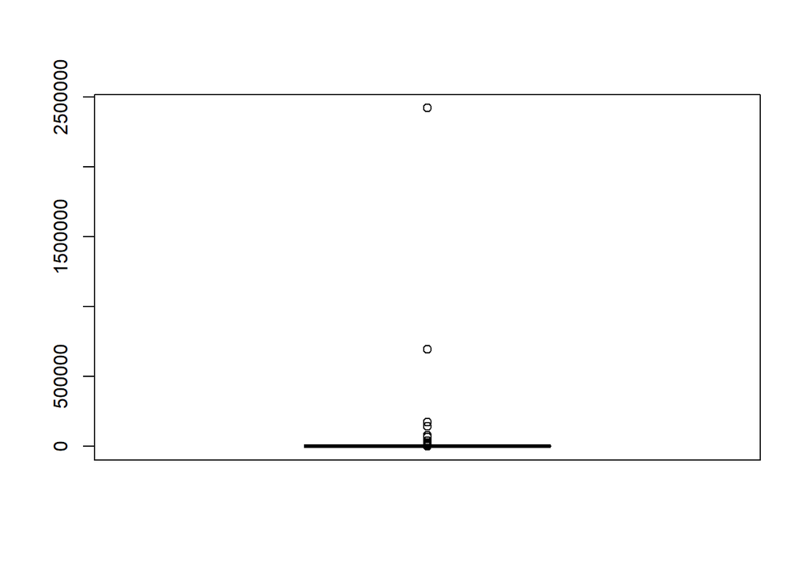

```r
boxplot(companies$X2015.PRICE.VAR....)
```

Vemos que para la mayoría de acciones sus precios fluctuan poco, sin embargo, tenemos valores muy anómalos, que nos indican que las acciones de ciertas empresas podrían subir más de un 500.000%. Como estas compañias aparecen de una manera muy poco lógica (los valores más altos incluso sería lógico pensar que son datos mal guardados), vamos a prescindir de ellas para centrarnos en empresas que siguen unas variaciones coherentes. Por lo tanto, vamos a eliminar todas aquellas compañias cuyo precio de las acciones aumente más de un 300%. (25 empresas)

```r
companies[companies$X2015.PRICE.VAR....>300,'X2015.PRICE.VAR....']
```

```
##  [1]    2292.8571    2248.6208   40233.2935     599.7488     400.6776
##  [6]    1993.9120    9864.8147     786.4865  173200.0031   19600.0005
## [11]   24166.6659     384.3750 2418600.9153    2933.3332    1000.6068
## [16]     460.3237    6799.9994    5843.1817   25199.9985  144358.8230
## [21]   66020.0018  695566.6720   78366.6715   13100.0000    1041.6666
```

```r
companies <- companies[companies$X2015.PRICE.VAR....<300,]
```

También hemos visto que existe alguna empresa cuya acciones pierden más del 100% de su valor, por lo cual será datos erróneos, así que también los eliminamos. (1 empresa)

```r
companies[companies$X2015.PRICE.VAR....< (-100),'X2015.PRICE.VAR....']
```

```
## [1] -100.3972
```

```r
companies <- companies[companies$X2015.PRICE.VAR....> (-100),]
```

Nos quedaría una variable ‘X2015.PRICE.VAR….’ tal que:

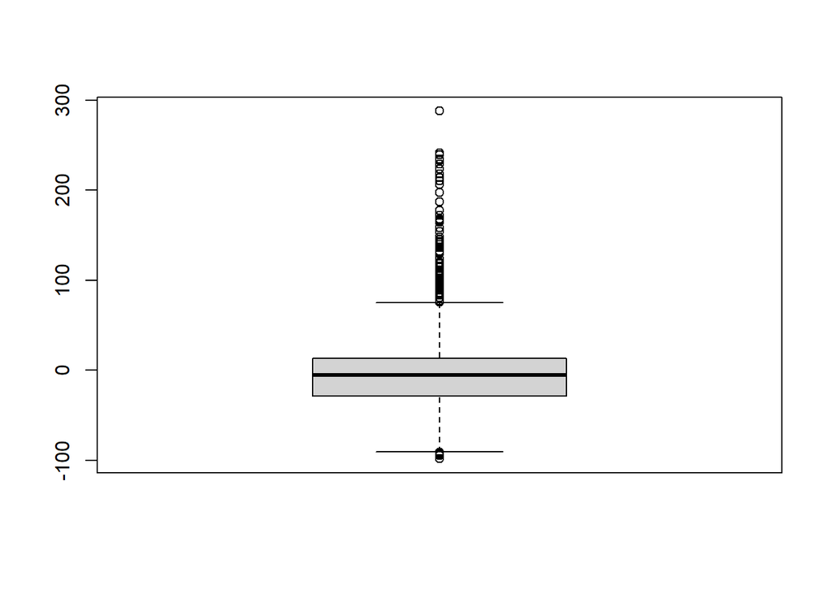

```r
boxplot(companies$X2015.PRICE.VAR....)
```

Tras este proceso procedemos a eliminar alguna columnas:

- La primera columna: el nombre de la empresa
- La columna que indica el sector al que pertenece la empresa.
- La penúltima columna, que se trata de ‘X2015.PRICE.VAR….’.

Además, covertimos el target en factor.

```r
companies_original <- companies
companies <- companies[-c(1, ncol(companies)-2, ncol(companies)-1)]
companies$Class <- as.factor(companies$Class)
```

Ahoora trataremos con los missing values:

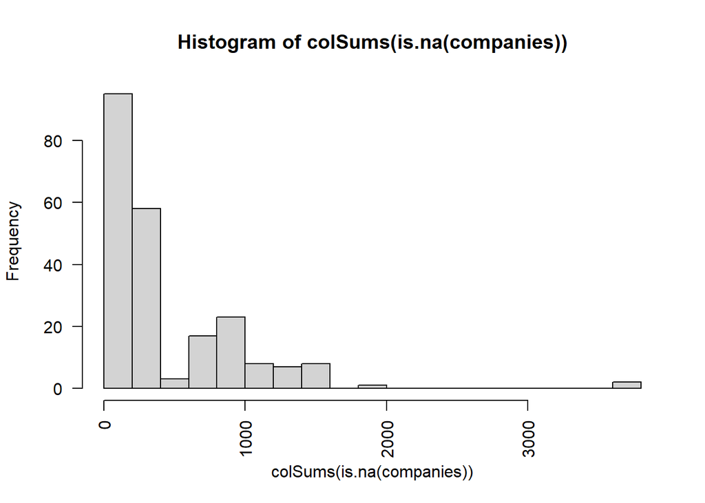

```r
hist(colSums(is.na(companies)), las=2, breaks = 20)
```

Decidimos eliminar las columnas que tengan un número significativo de NAs, unos 1000 (tenemos unas 4000 compañias), que representan más o menos un 25% de missing values por columna. (eliminamos 26 columnas)

```r
col_nas <- colSums(is.na(companies)) > 1000
sum(colSums(is.na(companies)) > 1000)
```

```
## [1] 26
```

```r
companies <- companies[!col_nas]
```

Ahora hacemos lo mismo con las observaciones, es decir, con las compañias.

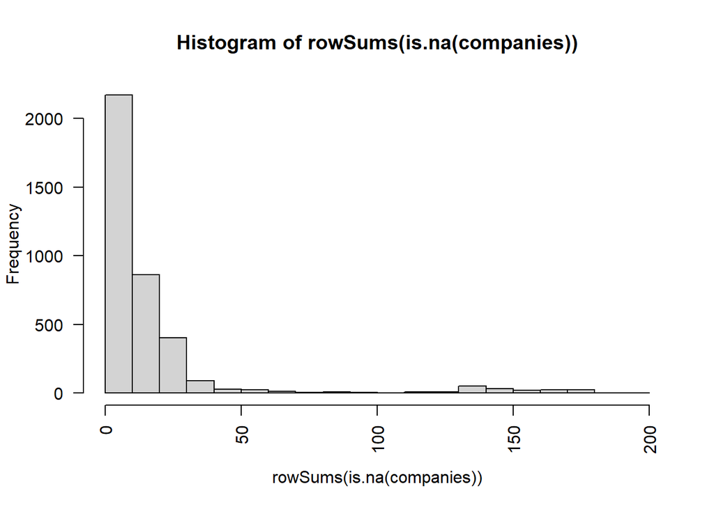

```r
hist(rowSums(is.na(companies)), las=2, breaks = 20)
```

Vamos a eliminar también las compañias que tengan por lo menos un cuarto de sus variables como missing values (≈ 50) (eliminamos 230 empresas).

```r
row_nas <- rowSums(is.na(companies)) > 50
sum(row_nas)
```

```
## [1] 230
```

```r
companies <- companies[!row_nas,]

companies_original <- companies_original[!row_nas,]
```

Procedemos al tratamiento de estos misiing values que los imputaremos con la media de cada columna:

```r
for(i in 1:ncol(companies)){
  if (colnames(companies)[i] != "Class"){
      companies[is.na(companies[,i]), i] <- mean(companies[,i], na.rm = TRUE)
  }
}
```

El siguiente paso que daremos será eliminar aquellas columnas con muy poca varianza: (eliminaremos una columna)

```r
zerovar <- nearZeroVar(companies)
companies <- companies[-zerovar]
```

En nuestro proceso de eliminar columnas para reducir la dimmensión pasaremos a eliminar columnas que tengan alta correlación con otras. Nos ayudaremos de la función findCorrelation que nos indicará que columna eliminar de cada par que tenga alta correlación.

```r
cor_matrix = cor(scale(companies[1:ncol(companies)-1]))
high_corr = findCorrelation(cor_matrix, cutoff=0.8)
high_corr = sort(high_corr)

companies = companies[,-c(high_corr)] # cuidado, puedo usar estos indices porque Class está en la última posición
```

Tras esta reducción de dimensionalidad vemos con cuantas columnas nos hemos quedado.

```r
ncol(companies)
```

```
## [1] 105
```

## Modelos de Regresión Avanzada

Comenzamos esta sección dividiendo el dataset en train y test para poder verificar el accuracy de nuestros modelos.

```r
partition <- sort(sample(nrow(companies), nrow(companies)*.7))

companies.train <- companies[partition,]
companies.test <- companies[-partition,]

companies_original.train <- companies_original[partition,]
companies_original.test <- companies_original[-partition,]
```

En primer lugar, vamos a tratar de hacer un modelo explicativo, por lo que necesitaremos pocas variables para que con éstas podamos explicar los resultados con los que nos vayamos a encontrar.

Teniendo en cuante que no tenemos gran conocimiento de finanzas, para seleccionar una pequeña cantidad de variables que den sentido a un modelo no las vamos a seleccionar mediante un criterio experto del que carecemos sino que, vamos a selecionar 8 de todo nuestro dataset mediante la realización de un clustering de variables:

```r
companies_traspose <- as.data.frame(t(companies.train[-ncol(companies.train)]))

pm <- eclust(companies_traspose, FUNcluster="pam", k = 8, hc_metric = "euclidean", hc_method = "ward.D2", graph = F)
medoids <- rownames(pm$medoids)

companies_cluster <- companies.train[, c(medoids, "Class")]
```

Vemos con que variables nos hemos quedado:

```r
medoids
```

```
## [1] "Intangibles.to.Total.Assets"     "Property..Plant...Equipment.Net"
## [3] "Deposit.Liabilities"             "Retained.earnings..deficit."
## [5] "Market.Cap"                      "Enterprise.Value"
## [7] "Working.Capital"                 "Net.Current.Asset.Value"
```

```r
summary(companies_cluster)
```

```
##  Intangibles.to.Total.Assets Property..Plant...Equipment.Net
##  Min.   :0.0000              Min.   :0.000e+00
##  1st Qu.:0.0000              1st Qu.:9.200e+06
##  Median :0.0372              Median :9.120e+07
##  Mean   :0.1429              Mean   :2.501e+09
##  3rd Qu.:0.2225              3rd Qu.:8.392e+08
##  Max.   :0.9274              Max.   :2.822e+11
##  Deposit.Liabilities Retained.earnings..deficit.   Market.Cap
##  Min.   :0.000e+00   Min.   :-8.557e+10          Min.   :0.000e+00
##  1st Qu.:0.000e+00   1st Qu.:-8.071e+07          1st Qu.:2.174e+08
##  Median :0.000e+00   Median : 4.020e+07          Median :1.018e+09
##  Mean   :5.554e+09   Mean   : 2.050e+09          Mean   :4.751e+10
##  3rd Qu.:0.000e+00   3rd Qu.: 6.551e+08          3rd Qu.:4.600e+09
##  Max.   :1.448e+12   Max.   : 4.084e+11          Max.   :9.619e+13
##  Enterprise.Value     Working.Capital      Net.Current.Asset.Value Class
##  Min.   :-1.252e+11   Min.   :-4.780e+12   Min.   :-1.894e+11      0:1448
##  1st Qu.: 3.025e+08   1st Qu.: 2.953e+07   1st Qu.:-2.301e+09      1:1038
##  Median : 1.706e+09   Median : 2.082e+08   Median :-1.755e+08
##  Mean   : 8.048e+09   Mean   : 2.170e+09   Mean   :-2.290e+09
##  3rd Qu.: 8.143e+09   3rd Qu.: 4.376e+09   3rd Qu.: 2.650e+07
##  Max.   : 4.348e+11   Max.   : 1.976e+12   Max.   : 5.333e+10
```

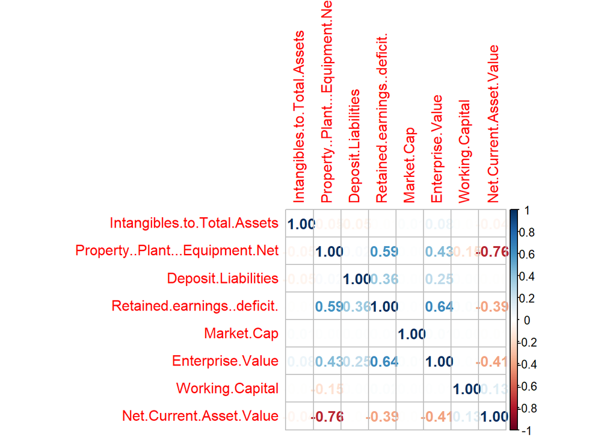

```r
corrplot(cor(companies_cluster[-9]), method = "number")
```

Nos hemos quedado por lo tanto con:

- “Intangibles.to.Total.Assets”: ratio de intangibles sobre activos totales.
- “Property..Plant…Equipment.Net”: activos físicos que una empresa no puede liquidar o vender fácilmente
- “Deposit.Liabilities”: depósito pasivo
- “Retained.earnings..deficit.”: déficit acumulado
- “Market.Cap”: capitalización del mercado
- “Enterprise.Value”: valor de la empresa
- “Working.Capital”: capital de trabajo
- “Net.Current.Asset.Value”: valor del activo

```r
logit.model <- glm(Class ~ .
                   + Intangibles.to.Total.Assets:Market.Cap
                   + Property..Plant...Equipment.Net:Working.Capital
                   + Working.Capital:Net.Current.Asset.Value
                   , family=binomial(link='logit'),
                   data=companies_cluster)
summary(logit.model)
```

```
##
## Call:
## glm(formula = Class ~ . + Intangibles.to.Total.Assets:Market.Cap +
##     Property..Plant...Equipment.Net:Working.Capital + Working.Capital:Net.Current.Asset.Value,
##     family = binomial(link = "logit"), data = companies_cluster)
##
## Deviance Residuals:
##     Min       1Q   Median       3Q      Max
## -2.2479  -1.0347  -0.9906   1.3026   2.2871
##
## Coefficients:
##                                                   Estimate Std. Error z value
## (Intercept)                                     -3.409e-01  5.493e-02  -6.206
## Intangibles.to.Total.Assets                     -1.990e-01  2.256e-01  -0.882
## Property..Plant...Equipment.Net                 -5.375e-11  1.302e-11  -4.127
## Deposit.Liabilities                             -2.114e-13  9.549e-13  -0.221
## Retained.earnings..deficit.                      4.520e-12  8.640e-12   0.523
## Market.Cap                                      -7.592e-12  4.569e-12  -1.662
## Enterprise.Value                                 1.276e-11  3.972e-12   3.212
## Working.Capital                                  4.275e-12  1.477e-12   2.894
## Net.Current.Asset.Value                         -1.973e-11  1.161e-11  -1.699
## Intangibles.to.Total.Assets:Market.Cap           3.030e-11  1.353e-11   2.240
## Property..Plant...Equipment.Net:Working.Capital -4.596e-22  1.545e-22  -2.975
## Working.Capital:Net.Current.Asset.Value         -6.068e-22  2.146e-22  -2.828
##                                                 Pr(>|z|)
## (Intercept)                                     5.45e-10 ***
## Intangibles.to.Total.Assets                      0.37774
## Property..Plant...Equipment.Net                 3.68e-05 ***
## Deposit.Liabilities                              0.82482
## Retained.earnings..deficit.                      0.60087
## Market.Cap                                       0.09657 .
## Enterprise.Value                                 0.00132 **
## Working.Capital                                  0.00380 **
## Net.Current.Asset.Value                          0.08934 .
## Intangibles.to.Total.Assets:Market.Cap           0.02508 *
## Property..Plant...Equipment.Net:Working.Capital  0.00293 **
## Working.Capital:Net.Current.Asset.Value          0.00469 **
## ---
## Signif. codes:  0 '***' 0.001 '**' 0.01 '*' 0.05 '.' 0.1 ' ' 1
##
## (Dispersion parameter for binomial family taken to be 1)
##
##     Null deviance: 3378.4  on 2485  degrees of freedom
## Residual deviance: 3307.1  on 2474  degrees of freedom
## AIC: 3331.1
##
## Number of Fisher Scoring iterations: 10
```

Si tratamos de dar una interpretación a los coeficientes (tomando exponenciales) vemos que nos dan resultados poco relevantes ya que se mantienen todos más o menos con valor 1 a excepción de ‘Intangibles.to.Total.Assets’ pero ya hemos visto que tenía poca significancia en el modelo:

```r
exp(coef(logit.model))
```

```
##                                     (Intercept)
##                                       0.7111469
##                     Intangibles.to.Total.Assets
##                                       0.8195280
##                 Property..Plant...Equipment.Net
##                                       1.0000000
##                             Deposit.Liabilities
##                                       1.0000000
##                     Retained.earnings..deficit.
##                                       1.0000000
##                                      Market.Cap
##                                       1.0000000
##                                Enterprise.Value
##                                       1.0000000
##                                 Working.Capital
##                                       1.0000000
##                         Net.Current.Asset.Value
##                                       1.0000000
##          Intangibles.to.Total.Assets:Market.Cap
##                                       1.0000000
## Property..Plant...Equipment.Net:Working.Capital
##                                       1.0000000
##         Working.Capital:Net.Current.Asset.Value
##                                       1.0000000
```

```r
probability <- predict(logit.model,
                       companies.test,
                       type='response')

prediction <- as.factor(ifelse(probability > 0.5,1,0))

confusionMatrix(prediction, companies.test$Class)
```

```
## Confusion Matrix and Statistics
##
##           Reference
## Prediction   0   1
##          0 597 435
##          1  16  18
##
##                Accuracy : 0.5769
##                  95% CI : (0.5466, 0.6068)
##     No Information Rate : 0.575
##     P-Value [Acc > NIR] : 0.4636
##
##                   Kappa : 0.0155
##
##  Mcnemar's Test P-Value : <2e-16
##
##             Sensitivity : 0.97390
##             Specificity : 0.03974
##          Pos Pred Value : 0.57849
##          Neg Pred Value : 0.52941
##              Prevalence : 0.57505
##          Detection Rate : 0.56004
##    Detection Prevalence : 0.96811
##       Balanced Accuracy : 0.50682
##
##        'Positive' Class : 0
##
```

Con este modelo tendríamos un acuracy bastante malo del 57% que es lo que nos devolvería el modelo naif según vemos en la distribución de Class en el set de test. Además, como podemos ver prácticamente todos los valores los predice como 0.

```r
prop.table(table(companies.test$Class))
```

```
##
##         0         1
## 0.5750469 0.4249531
```

Para mejorar estas predicciones trataremos de crear un modelo de regresión logística penalizada como puede ser Lasso o Ridge.

Probamos a realizar un primer modelo Ridge con todas las variables de nuestro train.

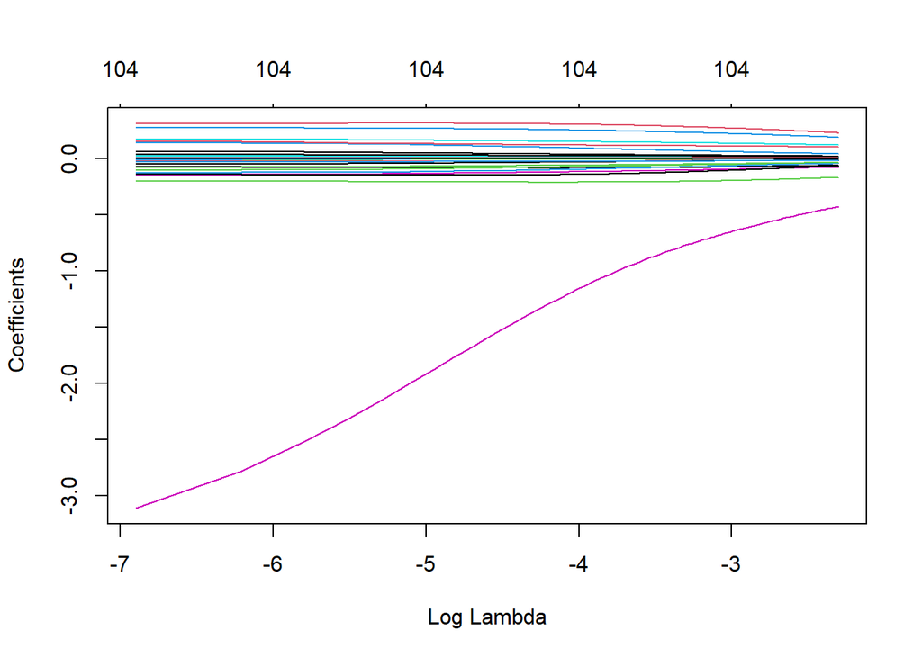

```r
ridge.model <- glmnet(as.matrix(companies.train[,-ncol(companies.train)]),
                      companies.train$Class,
                      family=c("binomial"),
                      alpha=0, # 0 = ridge, 1 = lasso
                      lambda=seq(0, .1, length = 100)
                      )
plot(ridge.model, xvar="lambda")
```

Para seleccionar el mejor lambda:

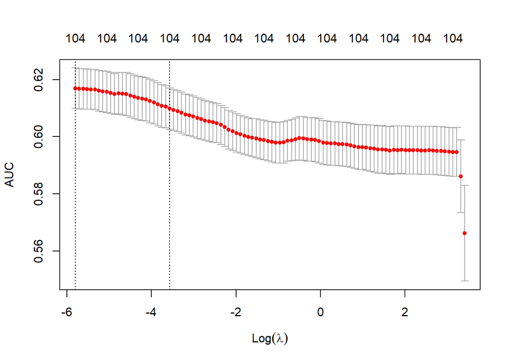

```r
ridge.cv = cv.glmnet(as.matrix(companies.train[,-ncol(companies.train)]),
                      companies.train$Class,
                      family=c("binomial"),
                      alpha=0, type.measure = "auc")
plot(ridge.cv)
```

El lambda que utilizaremos será:

```r
opt.lambda <- ridge.cv$lambda.min
opt.lambda
```

```
## [1] 0.003022771
```

Con esto elaboraremos un modelo y su predicción:

```r
ridge.model.lambda <- glmnet(as.matrix(companies.train[,-ncol(companies.train)]),
                      companies.train$Class,
                      family=c("binomial"),
                      alpha=0,
                      lambda=opt.lambda
                      )

probability <- predict(ridge.model.lambda,
                       as.matrix(companies.test[,-ncol(companies.train)]),
                       type='response')

prediction <- as.factor(ifelse(probability > 0.5,1,0))

confusionMatrix(prediction, companies.test$Class)
```

```
## Confusion Matrix and Statistics
##
##           Reference
## Prediction   0   1
##          0 542 331
##          1  71 122
##
##                Accuracy : 0.6229
##                  95% CI : (0.593, 0.6521)
##     No Information Rate : 0.575
##     P-Value [Acc > NIR] : 0.0008307
##
##                   Kappa : 0.1659
##
##  Mcnemar's Test P-Value : < 2.2e-16
##
##             Sensitivity : 0.8842
##             Specificity : 0.2693
##          Pos Pred Value : 0.6208
##          Neg Pred Value : 0.6321
##              Prevalence : 0.5750
##          Detection Rate : 0.5084
##    Detection Prevalence : 0.8189
##       Balanced Accuracy : 0.5767
##
##        'Positive' Class : 0
##
```

Usaremos la curva ROC para hacer una estimación de cual sería el threshold que optimizase las predicciones del modelo.

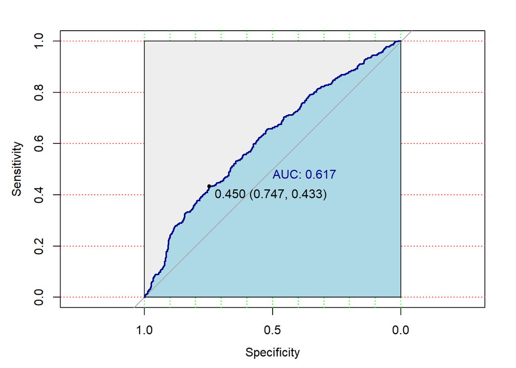

```r
plot.roc(companies.test$Class, probability,
         col="darkblue", print.auc = TRUE,  auc.polygon=TRUE, grid=c(0.1, 0.2),
         grid.col=c("green", "red"), max.auc.polygon=TRUE,
         auc.polygon.col="lightblue", print.thres=TRUE)
```

Obetenemos un área bajo la curva de 0.617.

Podemos ver cual sería el threshold que nos interesaría en la realidad.

Imaginemos que invertimos 100$ en cada acción que nos indica nuestro modelo. Como hemos guardado el dataset original y hemos borrado las mismas filas siempre, aún podemos acceder a la variable X2015.PRICE.VAR…. (que indicaba como variaba cada acción durante el año siguiente). De esta manera podemos prodecir cuanto ganaremos con cada compra de cada acción.

Así creamos un bucle y vemos las predicciones de nuestro modelo.

```r
profit.i = matrix(NA, nrow = 20, ncol = 9)

j <- 0
for (threshold in seq(0.1,0.9,0.1)){
  j <- j + 1
  for(i in 1:20){
    d <- createDataPartition(companies.train$Class, p = 0.4, list = FALSE)

    train <- companies.train[d,]
    test <- companies.train[-d,]
    train_original <- companies_original.train[d,]
    test_original <- companies_original.train[-d,]

    full.model = ridge.model.lambda <- glmnet(as.matrix(train[,-ncol(train)]),
                      train$Class,
                      family=c("binomial"),
                      alpha=0,
                      lambda=opt.lambda
                      )

    # probabilities
    probability = predict(full.model,
                          as.matrix(test[,-ncol(test)]),
                          type="response")

    # Predictions with a given threshold
    Cred.pred = as.factor(ifelse(probability > threshold, 1, 0))

    beneficts = 0

    for (k in 1:length(Cred.pred)){
      if(Cred.pred[k] == 1){
        beneficts = beneficts + (test_original$X2015.PRICE.VAR....[k]*100)
      }
    }

    profit.i[i,j] <- beneficts

  }
}
```

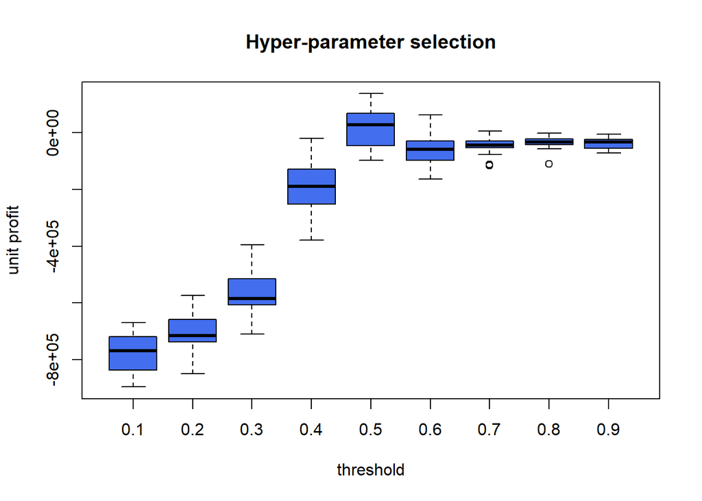

```r
boxplot(profit.i, main = "Hyper-parameter selection",
        ylab = "unit profit",
        xlab = "threshold",names = seq(0.1,0.9,0.1),col="royalblue2")
```

Como vemos parece que no tendríamos ganacias prácticamente con ningún threshold, así que parece claro que con este modelo lo mejor sería que no invirtieramos nada.